# Social Network Analysis

Worksheet 11: SAOMs I

Author

Termeh Shafie

# Introduction

In this practical we will estimate a **Stochastic Actor-Oriented Model (SAOM)** using the **Teenage Friends and Lifestyle Study**.

The data consist of:

- Three waves of friendship nominations among 129 pupils.
- Individual characteristics such as sex.
- Smoking behavior measured at each wave.

The goal is to learn how friendship networks evolve over time and how smoking behavior co-evolves with friendships.

## Load packages

```r
library(igraph)
library(networkdata)
library(RSiena)
```

## Load the data

The dataset contains three friendship networks measured over time.

```r
data("glasgow129")

glasgow_g1 <- glasgow129[[1]]
glasgow_g2 <- glasgow129[[2]]
glasgow_g3 <- glasgow129[[3]]
```

## Prepare the friendship networks

RSiena requires the network to be stored as a three-dimensional array:

- rows = sender
- columns = receiver
- third dimension = observation wave

```r
net1 <- as_adjacency_matrix(glasgow_g1, sparse = FALSE)
net2 <- as_adjacency_matrix(glasgow_g2, sparse = FALSE)
net3 <- as_adjacency_matrix(glasgow_g3, sparse = FALSE)

friendshipArray <- array(
  c(net1, net2, net3),
  dim = c(129,129,3)
)
```

# Model 1: Network dynamics only

We begin with a simple model that explains changes in friendship **using only structural network effects**.

# Creating the dependent network

The friendship network is the dependent variable.

The function `sienaDependent()` tells RSiena that this network changes over time and should be modelled.

```r
friendship <- sienaDependent(friendshipArray)
```

First we create a Siena data object.

```r
mydata1 <- sienaDataCreate(friendship)
```

Next we create an object that will contain the effects to estimate.

```r
myeff1 <- getEffects(mydata1)
```

Let’s inspect the default effects.

```r
myeff1
```

```
  effectName                          include fix   test  initialValue parm
1 constant friendship rate (period 1) TRUE    FALSE FALSE    7.45424   0
2 constant friendship rate (period 2) TRUE    FALSE FALSE    6.82927   0
3 outdegree (density)                 TRUE    FALSE FALSE   -1.61299   0
4 reciprocity                         TRUE    FALSE FALSE    0.00000   0
```

## Adding structural effects

We now add three common network mechanisms.

```r
myeff1 <- includeEffects(
  myeff1,
  outdegree,
  recip,
  transTrip
)
```

```
  effectNumber effectName          shortName include fix   test  initialValue
1 15           reciprocity         recip     TRUE    FALSE FALSE          0
2 21           transitive triplets transTrip TRUE    FALSE FALSE          0
  parm
1 0
2 0
```

These effects represent:

- **Outdegree (density):** baseline tendency to create friendships.
- **Reciprocity:** tendency to reciprocate friendships.
- **Transitive triplets:** tendency for friends of friends to become friends.

## Estimate the model

The estimation algorithm first needs to be specified.

```r
myalgorithm1 <- sienaAlgorithmCreate(
  projname="SAOM1",
  seed=12345
)
```

```
If you use this algorithm object, siena07 will create/use an output file SAOM1.txt .
```

Now estimate the model.

```r
result1 <- siena07(
  myalgorithm1,
  data=mydata1,
  effects=myeff1,
  batch=TRUE
)
```

```
Start phase 0
theta: -1.61  0.00  0.00

Start phase 1
Phase 1 Iteration 1 Progress: 0%
Phase 1 Iteration 2 Progress: 0%
Phase 1 Iteration 3 Progress: 0%
Phase 1 Iteration 4 Progress: 0%
Phase 1 Iteration 5 Progress: 0%
Phase 1 Iteration 10 Progress: 0%
Phase 1 Iteration 15 Progress: 1%
Phase 1 Iteration 20 Progress: 1%
Phase 1 Iteration 25 Progress: 1%
Phase 1 Iteration 30 Progress: 1%
Phase 1 Iteration 35 Progress: 1%
Phase 1 Iteration 40 Progress: 2%
Phase 1 Iteration 45 Progress: 2%
Phase 1 Iteration 50 Progress: 2%
theta: -1.722  0.282  0.113

Start phase 2.1
Phase 2 Subphase 1 Iteration 1 Progress: 8%
Phase 2 Subphase 1 Iteration 2 Progress: 8%
theta -1.755  0.366  0.147
ac 0.924 1.116 1.074
Phase 2 Subphase 1 Iteration 3 Progress: 8%
Phase 2 Subphase 1 Iteration 4 Progress: 8%
theta -1.862  0.627  0.254
ac 0.868 1.153 1.144
Phase 2 Subphase 1 Iteration 5 Progress: 8%
Phase 2 Subphase 1 Iteration 6 Progress: 8%
theta -1.987  0.921  0.372
ac 0.886 1.159 1.175
Phase 2 Subphase 1 Iteration 7 Progress: 8%
Phase 2 Subphase 1 Iteration 8 Progress: 8%
theta -2.129  1.252  0.475
ac 0.931 1.170 1.153
Phase 2 Subphase 1 Iteration 9 Progress: 8%
Phase 2 Subphase 1 Iteration 10 Progress: 8%
theta -2.246  1.541  0.486
```

[output cut: 38 more lines]

```
Phase 2 Subphase 4 Iteration 3 Progress: 40%
Phase 2 Subphase 4 Iteration 4 Progress: 40%
Phase 2 Subphase 4 Iteration 5 Progress: 40%
Phase 2 Subphase 4 Iteration 6 Progress: 40%
Phase 2 Subphase 4 Iteration 7 Progress: 40%
Phase 2 Subphase 4 Iteration 8 Progress: 40%
Phase 2 Subphase 4 Iteration 9 Progress: 40%
Phase 2 Subphase 4 Iteration 10 Progress: 40%
theta -2.639  2.177  0.462
ac -0.0717 -0.1472 -0.0711
theta: -2.639  2.177  0.462

Start phase 3
Phase 3 Iteration 500 Progress 81%
Phase 3 Iteration 1000 Progress 100%
```

Display the results.

```r
summary(result1)
```

```
Estimates, standard errors and convergence t-ratios

                                   Estimate   Standard   Convergence
                                                Error      t-ratio

Rate parameters:
  0.1      Rate parameter period 1 10.6606  ( 1.0645   )
  0.2      Rate parameter period 2  8.7846  ( 0.8342   )

Other parameters:
  1.  eval outdegree (density)     -2.6386  ( 0.0422   )   0.0671
  2.  eval reciprocity              2.1774  ( 0.0932   )   0.0688
  3.  eval transitive triplets      0.4622  ( 0.0294   )   0.1123

Overall maximum convergence ratio:    0.1188


Total of 1894 iteration steps.

Covariance matrix of estimates (correlations below diagonal)

       0.002       -0.002       -0.001
      -0.400        0.009       -0.001
      -0.453       -0.292        0.001

Derivative matrix of expected statistics X by parameters:

    1365.263      870.751     2440.256
     475.244      498.340     1266.413
    1958.805     1673.528     9163.139

Covariance matrix of X (correlations below diagonal):

    2065.855     1629.841     6964.869
       0.899     1592.616     6759.701
       0.732        0.809    43788.925
```

# Model 2: Adding actor covariates

Next we investigate whether friendships depend on:

- sex
- smoking

## Sex

The sex variable does not change over time.

Therefore it is entered as a **constant covariate**.

```r
sex <- ifelse(
  V(glasgow_g2)$sex.F=="F",
  1,
  0
)

sexCov <- coCovar(sex)
```

## Smoking

Smoking is observed at every wave.

We therefore create a changing covariate.

```r
smoke <- cbind(
  as.numeric(V(glasgow_g1)$tobacco),
  as.numeric(V(glasgow_g2)$tobacco),
  as.numeric(V(glasgow_g3)$tobacco)
)

smokeCov <- varCovar(smoke)
```

## Create the new Siena data object

```r
mydata2 <- sienaDataCreate(
  friendship,
  sexCov,
  smokeCov
)
```

```r
myeff2 <- getEffects(mydata2)
```

## Add covariate effects

For each covariate we estimate three effects.

```r
myeff2 <- includeEffects(
  myeff2,
  egoX,
  altX,
  simX,
  interaction1="sexCov"
)
```

```
  effectNumber effectName        shortName include fix   test  initialValue
1 264          sexCov alter      altX      TRUE    FALSE FALSE          0
2 279          sexCov ego        egoX      TRUE    FALSE FALSE          0
3 325          sexCov similarity simX      TRUE    FALSE FALSE          0
  parm
1 0
2 0
3 0
```

```r
myeff2 <- includeEffects(
  myeff2,
  egoX,
  altX,
  simX,
  interaction1="smokeCov"
)
```

```
  effectNumber effectName          shortName include fix   test  initialValue
1 448          smokeCov alter      altX      TRUE    FALSE FALSE          0
2 463          smokeCov ego        egoX      TRUE    FALSE FALSE          0
3 509          smokeCov similarity simX      TRUE    FALSE FALSE          0
  parm
1 0
2 0
3 0
```

These correspond to:

- **ego effect:** Does this type of actor nominate more friends?
- **alter effect:** Are actors with this characteristic more popular?
- **similarity effect:** Do similar actors become friends?

## Estimate Model 2

```r
myalgorithm2 <- sienaAlgorithmCreate(
  projname="SAOM2",
  seed=12345
)
```

```
If you use this algorithm object, siena07 will create/use an output file SAOM2.txt .
```

```r
result2 <- siena07(
  myalgorithm2,
  data=mydata2,
  effects=myeff2,
  batch=TRUE
)
```

```
Start phase 0
theta: -1.61  0.00  0.00  0.00  0.00  0.00  0.00  0.00

Start phase 1
Phase 1 Iteration 1 Progress: 0%
Phase 1 Iteration 2 Progress: 0%
Phase 1 Iteration 3 Progress: 0%
Phase 1 Iteration 4 Progress: 0%
Phase 1 Iteration 5 Progress: 0%
Phase 1 Iteration 10 Progress: 0%
Phase 1 Iteration 15 Progress: 0%
Phase 1 Iteration 20 Progress: 1%
Phase 1 Iteration 25 Progress: 1%
Phase 1 Iteration 30 Progress: 1%
Phase 1 Iteration 35 Progress: 1%
Phase 1 Iteration 40 Progress: 1%
Phase 1 Iteration 45 Progress: 1%
Phase 1 Iteration 50 Progress: 2%
theta: -1.68133  0.32727 -0.02170  0.01601  0.07934  0.00680  0.00077  0.08581

Start phase 2.1
Phase 2 Subphase 1 Iteration 1 Progress: 14%
Phase 2 Subphase 1 Iteration 2 Progress: 14%
theta -1.725465  0.534183 -0.033884  0.026220  0.130621  0.009735  0.000769  0.135120
ac 0.920 1.134 1.080 0.829 1.181 9.733 1.552 1.397
Phase 2 Subphase 1 Iteration 3 Progress: 14%
Phase 2 Subphase 1 Iteration 4 Progress: 14%
theta -1.87129  1.18486 -0.07152  0.05461  0.28941  0.02781  0.00599  0.28414
ac 0.935 1.181 0.924 1.052 1.228 5.969 1.538 1.473
Phase 2 Subphase 1 Iteration 5 Progress: 14%
Phase 2 Subphase 1 Iteration 6 Progress: 14%
theta -2.0539  1.8856 -0.0936  0.0785  0.4710  0.0412  0.0152  0.3994
ac 0.962 1.192 1.014 1.158 1.225 1.812 1.412 1.484
Phase 2 Subphase 1 Iteration 7 Progress: 14%
Phase 2 Subphase 1 Iteration 8 Progress: 14%
theta -2.2518  2.3224 -0.0871  0.1050  0.6927  0.0409  0.0346  0.4577
ac 0.986 1.180 1.188 1.216 1.213 1.626 1.405 1.375
Phase 2 Subphase 1 Iteration 9 Progress: 14%
Phase 2 Subphase 1 Iteration 10 Progress: 14%
theta -2.4044  2.4850 -0.0592  0.1109  0.8201  0.0377  0.0453  0.4276
```

[output cut: 38 more lines]

```
Phase 2 Subphase 4 Iteration 3 Progress: 44%
Phase 2 Subphase 4 Iteration 4 Progress: 44%
Phase 2 Subphase 4 Iteration 5 Progress: 44%
Phase 2 Subphase 4 Iteration 6 Progress: 44%
Phase 2 Subphase 4 Iteration 7 Progress: 44%
Phase 2 Subphase 4 Iteration 8 Progress: 44%
Phase 2 Subphase 4 Iteration 9 Progress: 44%
Phase 2 Subphase 4 Iteration 10 Progress: 44%
theta -2.62789  2.49425 -0.12769  0.17550  0.98194  0.05515  0.00273  0.42459
ac -0.00709  0.11036 -0.07095  0.02080 -0.05686 -0.01517 -0.06179 -0.01688
theta: -2.62789  2.49425 -0.12769  0.17550  0.98194  0.05515  0.00273  0.42459

Start phase 3
Phase 3 Iteration 500 Progress 84%
Phase 3 Iteration 1000 Progress 100%
```

```r
summary(result2)
```

```
Estimates, standard errors and convergence t-ratios

                                   Estimate   Standard   Convergence
                                                Error      t-ratio

Rate parameters:
  0.1      Rate parameter period 1  8.8650  ( 0.7610   )
  0.2      Rate parameter period 2  7.5790  ( 0.5836   )

Other parameters:
  1.  eval outdegree (density)     -2.6279  ( 0.0477   )    0.0140
  2.  eval reciprocity              2.4942  ( 0.0835   )   -0.0103
  3.  eval sexCov alter            -0.1277  ( 0.0946   )    0.0058
  4.  eval sexCov ego               0.1755  ( 0.0954   )    0.0572
  5.  eval sexCov similarity        0.9819  ( 0.0856   )   -0.0205
  6.  eval smokeCov alter           0.0552  ( 0.0637   )   -0.0144
  7.  eval smokeCov ego             0.0027  ( 0.0675   )    0.0613
  8.  eval smokeCov similarity      0.4246  ( 0.1193   )   -0.0230

Overall maximum convergence ratio:    0.1306


Total of 2803 iteration steps.

Covariance matrix of estimates (correlations below diagonal)

       0.002       -0.002        0.001       -0.001       -0.002        0.000        0.000       -0.001
      -0.437        0.007       -0.001        0.001        0.000        0.000        0.000       -0.001
       0.207       -0.071        0.009       -0.007       -0.002        0.000        0.000        0.001
      -0.220        0.073       -0.724        0.009        0.002        0.000       -0.001       -0.001
      -0.566       -0.059       -0.206        0.256        0.007        0.000        0.000        0.000
      -0.029       -0.061       -0.063       -0.026        0.041        0.004        0.000        0.003
       0.024       -0.052       -0.020       -0.134        0.005       -0.074        0.005        0.004
      -0.105       -0.086        0.051       -0.053       -0.024        0.437        0.444        0.014

Derivative matrix of expected statistics X by parameters:

     886.020      550.999      -39.179      -19.293      326.879      -63.568      -73.563       91.098
     305.167      384.190       -6.474       -5.057      125.179      -18.767      -20.962       38.533
     -35.182      -11.610      222.483      173.328      -12.164       58.385       60.186      -29.692
     -18.794      -18.768      174.248      216.672      -27.408       54.193       61.163      -23.835
     323.766      224.861      -13.206      -25.789      232.628      -26.874      -29.579       33.433
     -63.515      -37.631       65.918       52.678      -21.790      294.414      142.499     -103.710
     -78.885      -45.105       59.313       70.799      -28.159      137.432      277.757     -101.648
      97.076       73.663      -32.906      -33.076       39.056     -104.795     -100.765      115.947

Covariance matrix of X (correlations below diagonal):

     769.131      564.071      -19.450       -6.342      308.042      -50.363      -55.530       80.344
       0.790      663.309       -5.170       -2.196      245.967      -38.650      -37.269       72.746
      -0.051       -0.015      190.808      155.126       -6.996       51.392       42.141      -21.379
      -0.017       -0.006        0.835      180.717      -12.623       42.802       48.042      -21.352
       0.766        0.659       -0.035       -0.065      210.301      -10.160      -12.915       28.810
      -0.118       -0.097        0.241        0.207       -0.045      237.445      133.989      -86.320
      -0.133       -0.096        0.203        0.238       -0.059        0.578      226.386      -81.709
       0.294        0.287       -0.157       -0.161        0.202       -0.568       -0.551       97.158
```

# Model 3: Co-evolution of friendship and smoking

So far smoking has only been treated as a covariate.

Now we allow smoking itself to change over time.

We therefore model **two dependent variables simultaneously**:

- friendship
- smoking behavior

```r
smoking <- sienaDependent(
  smoke,
  type="behavior"
)
```

## Create the co-evolution dataset

```r
mydata3 <- sienaDataCreate(
  friendship,
  smoking,
  sexCov
)

myeff3 <- getEffects(mydata3)
```

## Friendship dynamics

We include the same structural effects as before.

```r
myeff3 <- includeEffects(
  myeff3,
  outdegree,
  recip,
  transTrip,
  name="friendship"
)
```

```
  effectNumber effectName          shortName include fix   test  initialValue
1 17           reciprocity         recip     TRUE    FALSE FALSE          0
2 23           transitive triplets transTrip TRUE    FALSE FALSE          0
  parm
1 0
2 0
```

## Behavior dynamics

We now model changes in smoking.

```r
myeff3 <- includeEffects(
  myeff3,
  linear,
  quad,
  name="smoking"
)
```

```
  effectNumber effectName              shortName include fix   test
1 689          smoking linear shape    linear    TRUE    FALSE FALSE
2 692          smoking quadratic shape quad      TRUE    FALSE FALSE
  initialValue parm
1   -0.58955   0
2    0.00000   0
```

The behavioral objective function now estimates:

- **Linear shape:** Is higher smoking generally more or less attractive?
- **Quadratic shape:** Are moderate or extreme smoking levels preferred?

## Social influence

Finally we estimate peer influence.

```r
myeff3 <- includeEffects(
  myeff3,
  avAlt,
  name="smoking",
  interaction1="friendship"
)
```

```
  effectNumber effectName            shortName include fix   test  initialValue
1 778          smoking average alter avAlt     TRUE    FALSE FALSE          0
  parm
1 0
```

This tests whether students tend to become more similar to the average smoking behavior of their friends.

## Estimate the co-evolution model

```r
myalgorithm3 <- sienaAlgorithmCreate(
  projname="SAOM3",
  seed=12
)
```

```
If you use this algorithm object, siena07 will create/use an output file SAOM3.txt .
```

```r
result3 <- siena07(
  myalgorithm3,
  data = mydata3,
  effects = myeff3,
  batch = TRUE,
  returnDeps = TRUE
)
```

```
Start phase 0
theta:  7.454  6.829 -1.613  0.000  0.000  0.472  0.423 -0.590  0.000  0.000

Start phase 1
Phase 1 Iteration 1 Progress: 0%
Phase 1 Iteration 2 Progress: 0%
Phase 1 Iteration 3 Progress: 0%
Phase 1 Iteration 4 Progress: 0%
Phase 1 Iteration 5 Progress: 0%
Phase 1 Iteration 10 Progress: 0%
Phase 1 Iteration 15 Progress: 0%
Phase 1 Iteration 20 Progress: 1%
Phase 1 Iteration 25 Progress: 1%
Phase 1 Iteration 30 Progress: 1%
Phase 1 Iteration 35 Progress: 1%
Phase 1 Iteration 40 Progress: 1%
Phase 1 Iteration 45 Progress: 1%
Phase 1 Iteration 50 Progress: 1%
theta:  7.7352  6.5283 -1.7148  0.2187  0.1403  0.4609  0.4982 -0.6127 -0.0482  1.0000

Start phase 2.1
Phase 2 Subphase 1 Iteration 1 Progress: 16%
Phase 2 Subphase 1 Iteration 2 Progress: 16%
theta  7.8490  6.4278 -1.7661  0.3228  0.2086  0.4620  0.5331 -0.6109 -0.0659  1.4482
ac 2.029 1.528 0.995 1.108 1.138 0.885 1.617 1.199 1.124 1.088
Phase 2 Subphase 1 Iteration 3 Progress: 16%
Phase 2 Subphase 1 Iteration 4 Progress: 16%
theta  8.3692  6.3065 -1.9346  0.6814  0.4121  0.4802  0.6411 -0.6376 -0.0539  3.0664
ac 1.431 1.505 0.910 1.167 1.193 0.697 0.548 0.859 1.061 1.306
Phase 2 Subphase 1 Iteration 5 Progress: 16%
Phase 2 Subphase 1 Iteration 6 Progress: 16%
theta  8.720  6.728 -2.113  1.156  0.500  0.573  0.757 -0.814  0.360  4.764
ac 1.400 1.254 1.030 1.172 1.246 0.732 0.549 0.958 1.103 1.339
Phase 2 Subphase 1 Iteration 7 Progress: 16%
Phase 2 Subphase 1 Iteration 8 Progress: 16%
theta  8.664  7.133 -2.255  1.579  0.449  0.791  0.860 -1.252  1.122  6.240
ac 1.446 1.227 1.097 1.169 1.331 0.774 0.364 0.667 1.123 1.254
Phase 2 Subphase 1 Iteration 9 Progress: 16%
Phase 2 Subphase 1 Iteration 10 Progress: 16%
theta  8.849  7.598 -2.390  1.934  0.412  0.901  0.949 -1.812  1.675  6.596
```

[output cut: 48 more lines]

```
Phase 2 Subphase 4 Iteration 3 Progress: 46%
Phase 2 Subphase 4 Iteration 4 Progress: 46%
Phase 2 Subphase 4 Iteration 5 Progress: 46%
Phase 2 Subphase 4 Iteration 6 Progress: 46%
Phase 2 Subphase 4 Iteration 7 Progress: 46%
Phase 2 Subphase 4 Iteration 8 Progress: 46%
Phase 2 Subphase 4 Iteration 9 Progress: 46%
Phase 2 Subphase 4 Iteration 10 Progress: 46%
theta 10.652  8.719 -2.630  2.170  0.458  4.237  3.522 -3.824  3.057  2.013
ac  0.10618  0.01752 -0.03423 -0.12617 -0.16822  0.28303  0.36789  0.08696  0.00477  0.04506
theta: 10.652  8.719 -2.630  2.170  0.458  4.237  3.522 -3.824  3.057  2.013

Start phase 3
Phase 3 Iteration 500 Progress 85%
Phase 3 Iteration 1000 Progress 100%
```

```r
summary(result3)
```

```
Estimates, standard errors and convergence t-ratios

                                               Estimate   Standard   Convergence
                                                            Error      t-ratio
Network Dynamics
   1. rate constant friendship rate (period 1) 10.6525  ( 1.0666   )   -0.0800
   2. rate constant friendship rate (period 2)  8.7185  ( 0.8924   )   -0.1003
   3. eval outdegree (density)                 -2.6301  ( 0.0416   )    0.0233
   4. eval reciprocity                          2.1696  ( 0.0925   )    0.0112
   5. eval transitive triplets                  0.4581  ( 0.0287   )   -0.0117

Behavior Dynamics
   6. rate rate smoking (period 1)              4.2365  ( 1.4498   )   -0.2653
   7. rate rate smoking (period 2)              3.5222  ( 1.0394   )   -0.3636
   8. eval smoking linear shape                -3.8244  ( 0.4564   )    0.0583
   9. eval smoking quadratic shape              3.0574  ( 0.4022   )    0.1809
  10. eval smoking average alter                2.0130  ( 0.8836   )    0.2322

Overall maximum convergence ratio:    0.9568


Total of 3126 iteration steps.

Covariance matrix of estimates (correlations below diagonal)

       1.138       -0.131        0.008       -0.016       -0.002        0.514        0.102       -0.047        0.034       -0.072
      -0.138        0.796        0.000       -0.008        0.003        0.026        0.117       -0.042        0.033        0.041
       0.191       -0.012        0.002       -0.002       -0.001        0.010        0.000       -0.001        0.000        0.002
      -0.165       -0.102       -0.396        0.009       -0.001       -0.022        0.004        0.002       -0.001       -0.006
      -0.079        0.122       -0.437       -0.309        0.001        0.000        0.000        0.000        0.001        0.000
       0.333        0.020        0.166       -0.161        0.000        2.102        0.128       -0.073        0.067       -0.227
       0.092        0.126       -0.001        0.042        0.013        0.085        1.080       -0.172        0.120       -0.289
      -0.096       -0.103       -0.041        0.058       -0.033       -0.111       -0.362        0.208       -0.170       -0.183
       0.080        0.093        0.013       -0.028        0.056        0.115        0.288       -0.926        0.162        0.143
      -0.077        0.052        0.060       -0.071        0.018       -0.177       -0.315       -0.453        0.403        0.781

Derivative matrix of expected statistics X by parameters:

      18.078        0.000        2.134        3.622       26.589        1.151        0.000        0.803        0.685       -0.052
       0.000       18.873        0.918        2.076        8.729        0.000        0.007       -0.333       -0.475       -1.420
     174.590      162.420     1314.240      829.488     2687.800      -21.744       -9.477      -17.482      -20.673       -9.855
      35.160       11.272      460.085      484.602     1206.157       -4.031      -10.005      -14.205      -16.763       -2.588
     293.847      162.914     1966.573     1669.618     9760.987      -22.797      -24.881      -50.373      -66.690      -20.074
      -6.615        0.000       -1.301        0.647       -4.380        3.405        0.000        1.474        2.664        1.209
       0.000       -3.877       -4.144       -3.641      -10.333        0.000        8.896        7.757        9.308        5.098
      -4.904       -1.689      -17.909      -15.520      -83.718       24.689       24.570       79.219       90.217       35.575
      -3.227       -0.933      -20.261      -20.206     -107.511       16.742       11.330       69.094       85.404       32.026
      -1.184       -1.407       -4.238       -1.795      -15.960        3.930        7.330       10.860       11.744       16.087

Covariance matrix of X (correlations below diagonal):

     382.977       -5.646      262.180      158.533     1267.447       -6.099        4.370       -4.038       -7.862       -5.900
      -0.016      322.672      210.522      108.395      911.495        3.181       -4.047       -3.075       -3.444       -7.140
       0.305        0.267     1929.418     1512.375     7156.425      -13.647      -16.774      -26.688      -35.665      -16.551
       0.212        0.158        0.903     1453.911     6500.039       -5.595      -19.525      -23.697      -33.361      -15.510
       0.301        0.236        0.758        0.793    46185.505      -47.038      -67.020     -162.950     -224.604     -154.132
      -0.047        0.027       -0.047       -0.022       -0.033       43.901       -0.047       46.116       52.171       18.936
       0.032       -0.032       -0.055       -0.074       -0.045       -0.001       48.390       45.909       51.314       29.636
      -0.017       -0.014       -0.051       -0.052       -0.064        0.587        0.557      140.630      162.241       78.327
      -0.029       -0.014       -0.058       -0.062       -0.074        0.560        0.525        0.973      197.657       96.033
      -0.026       -0.034       -0.033       -0.035       -0.062        0.247        0.368        0.571        0.590      133.837
```

**Important**

To use `sienaGOF()`which we do in the next seection, the model must be estimated with `returnDeps = TRUE`, so that RSiena stores the simulated dependent variables needed for the goodness-of-fit checks.

# Optional: nicer tables

```r
siena_table(result1, type = "html", sig = TRUE)
siena_table(result2, type = "html", sig = TRUE)
siena_table(result3, type = "html", sig = TRUE)
```

## Goodness of Fit

Estimating a SAOM is only the first step. As with Exponential Random Graph Models (ERGMs), it is good practice to assess **how well the fitted model reproduces the observed data**.

The basic idea is to:

1. Simulate many networks from the fitted model.
2. Compare characteristics of the simulated networks with those of the observed network.
3. Evaluate whether the observed network looks typical under the fitted model.

If the observed network falls well within the distribution of simulated networks, this provides evidence that the model adequately captures that aspect of the data.

Formally, the goodness-of-fit assessment tests the **null hypothesis that the fitted SAOM is capable of generating networks with the same structural properties as the observed network**. The plots compare the observed statistic (typically shown as a vertical line or point) with the distribution of the same statistic across networks simulated from the fitted model. The accompanying $p$-value quantifies how unusual the observed statistic is under the fitted model. A large $p$-value (commonly greater than 0.05) indicates that the observed network is consistent with the simulations, suggesting an adequate fit for that network feature. A small $p$-value indicates that the observed statistic lies in the tails of the simulated distribution, implying that the model does not reproduce that particular aspect of the network well and may require additional effects or refinements.

### Goodness of fit: Indegree distribution

First, we assess whether the fitted model reproduces the **indegree distribution** (i.e., how many friendship nominations each student receives).

The function `sienaGOF()` requires:

- `sienaFitObject`: the fitted SAOM.
- `auxiliaryFunction`: the network statistic to assess.
- `varName`: the dependent network or behavior.

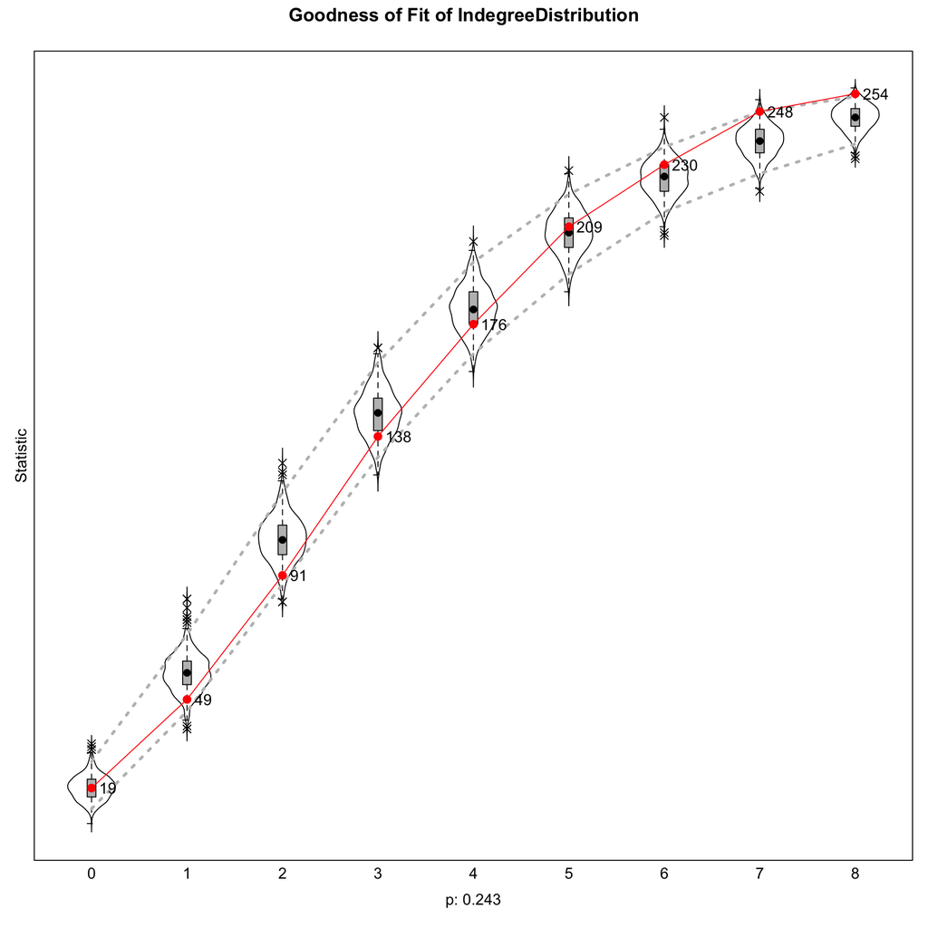

```r
gof_indegree <- sienaGOF(
  result3,
  IndegreeDistribution,
  varName = "friendship"
)

plot(gof_indegree)
```

Interpret the figure by comparing the observed indegree distribution (solid line) with the distribution obtained from the simulated networks (boxplots).

### Goodness of fit: Smoking behavior

Next, we assess whether the model reproduces the observed distribution of smoking behavior.

```
Note: some statistics are not plotted because their variance is 0.
This holds for the statistic: 3.
```

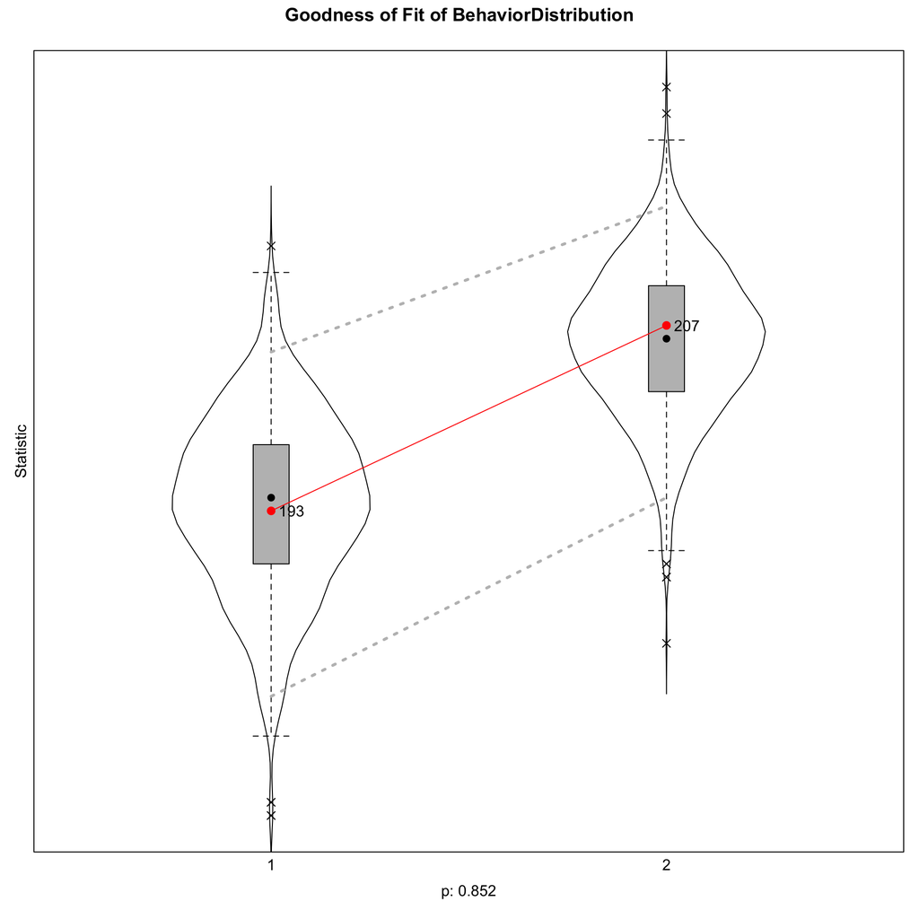

```r
gof_behavior <- sienaGOF(
  result3,
  BehaviorDistribution,
  varName = "smoking"
)

plot(gof_behavior)
```

Again, compare the observed behavior distribution with the simulated distributions.

**Why assess goodness of fit for smoking behaviour?**

Although smoking behaviour is modelled directly in Model 3, it is still useful to assess its goodness of fit. The estimated parameters are chosen to explain **how smoking changes over time**, not to perfectly reproduce every feature of the observed data.

A behavioural goodness-of-fit check asks whether simulations from the fitted model generate a distribution of smoking behaviour similar to the one observed in the data. If the simulated and observed distributions are similar, this provides evidence that the model adequately captures the overall behavioural dynamics. If they differ substantially, the model may be missing important behavioural processes, even if individual parameter estimates appear reasonable.

The parameters in a SAOM define an actor-oriented objective function governing the micro-steps of network and behavioural change. The estimation procedure is not matching the final distribution of smoking behaviour in the same way an ERGM matches sufficient statistics. In other words, the ERGM is matching network statistics directly, whereas the SAOM is estimating a dynamic process whose consequences can still be checked using GOF diagnostics.

## Discussion Questions

After estimating **Model 3 (Co-evolution of Friendship and Smoking)**, answer the following questions.

1. **Friendship dynamics:** Is there evidence that friendship ties are shaped by **reciprocity** and **transitive triplets**? Interpret the estimated coefficients for these structural effects.
2. **Network structure:** What does the **negative outdegree (density)** parameter imply about the overall tendency to form friendships in the network?
3. **Behavior dynamics:** What do the **linear shape** and **quadratic shape** parameters indicate about changes in smoking behavior over time? Do they suggest that students tend to move toward lower, higher, or moderate levels of smoking?
4. **Social influence:** Does the **average alter (`avAlt`)** effect provide evidence that students’ smoking behavior is influenced by the smoking behavior of their friends? Interpret both the sign and magnitude of this parameter.
5. **Statistical significance:** Which estimated parameters appear to be statistically significant (using the estimates and standard errors)? What do these significant effects tell us about friendship evolution and smoking behavior?
6. **Model convergence:** Assess the convergence of the model.
   - What is the overall maximum convergence ratio?
   - Is it below the recommended threshold (preferably < 0.10, acceptable < 0.25)?
   - Based on the convergence diagnostics, would you consider the parameter estimates reliable? Explain your reasoning.
   - If convergence is poor, what changes to the model or estimation procedure might improve it?
7. **Goodness of fit (Network):** Does the fitted model adequately reproduce the **indegree distribution**? Use the goodness-of-fit plot to justify your answer.
8. **Goodness of fit (Behavior):** Does the fitted model adequately reproduce the **distribution of smoking behavior**? What aspects of the observed distribution are well captured, and where does the model perform poorly?
9. **Overall assessment:** Considering the parameter estimates, convergence diagnostics, and goodness-of-fit results, how well does the co-evolution SAOM explain the joint evolution of friendship ties and smoking behavior? What limitations of the model remain?